# CFRM 502, Winter 2020

# Instructor: Bahman Angoshtari

# Solution to Homework 5

$\newcommand\Fc{\mathscr{F}}$ $\newcommand{\eps}{\varepsilon}$ $\newcommand{\Var}{\operatorname{Var}}$ $\newcommand\Cov{\operatorname{Cov}}$ $\newcommand\Corr{\operatorname{Corr}}$ $\newcommand{\sig}{\sigma}$ $\newcommand\Sig{\Sigma}$ $\newcommand{\al}{\alpha}$ $\newcommand{\gam}{\gamma}$ $\newcommand\Gam{\Gamma}$ $\newcommand\lam{\lambda}$ $\newcommand{\Del}{\Delta}$ $\newcommand\tht{\theta}$ $\newcommand\ph{\varphi}$ $\newcommand\om{\omega}$ $\newcommand\Om{\Omega}$ $\newcommand\rb{\bar{r}}$ $\newcommand{\Xb}{\bar{X}}$ $\newcommand{\Yb}{\bar{Y}}$ $\newcommand\Eb{\mathbb{E}}$ $\newcommand\Pb{\mathbb{P}}$ $\newcommand\Qb{\mathbb{Q}}$ $\newcommand\Rb{\mathbb{R}}$ $\newcommand\Zb{\mathbb{Z}}$ $\newcommand\Nb{\mathbb{N}}$ $\newcommand\Av{\textbf{A}}$ $\newcommand\Ev{\textbf{E}}$ $\newcommand\Dv{\textbf{D}}$ $\newcommand\Fv{\textbf{F}}$ $\newcommand\Gv{\textbf{G}}$ $\newcommand\Hv{\textbf{H}}$ $\newcommand\Kv{\textbf{K}}$ $\newcommand\Iv{\textbf{I}}$ $\newcommand\Pv{\textbf{P}}$ $\newcommand\Ov{\textbf{O}}$ $\newcommand\Sv{\textbf{S}}$ $\newcommand\Xv{\textbf{X}}$ $\newcommand\Yv{\textbf{Y}}$ $\newcommand\Zv{\textbf{Z}}$ $\newcommand\av{\mathbf{a}}$ $\newcommand\xv{\mathbf{x}}$ $\newcommand\yv{\mathbf{y}}$ $\newcommand\zv{\mathbf{z}}$ $\newcommand\Cv{\mathbf{C}}$ $\newcommand\mv{\mathbf{m}}$ $\newcommand\nv{\mathbf{n}}$ $\newcommand\pv{\mathbf{p}}$ $\newcommand\sv{\mathbf{s}}$ $\newcommand\wv{\mathbf{w}}$ $\newcommand\Wv{\textbf{W}}$ $\newcommand\alv{{\boldsymbol\al}}$ $\newcommand\betav{{\boldsymbol\beta}}$ $\newcommand\etav{{\boldsymbol\eta}}$ $\newcommand\epsv{{\boldsymbol\varepsilon}}$ $\newcommand\delv{{\boldsymbol\delta}}$ $\newcommand\Lamv{{\boldsymbol\Lambda}}$ $\newcommand\lamv{{\boldsymbol\lambda}}$ $\newcommand\muv{{\boldsymbol\mu}}$ $\newcommand\piv{{\boldsymbol\pi}}$ $\newcommand\Piv{{\boldsymbol\Pi}}$ $\newcommand\Gamv{{\boldsymbol\Gam}}$ $\newcommand\Phiv{{\boldsymbol\Phi}}$ $\newcommand\Sigv{{\boldsymbol\Sig}}$ $\newcommand\ah{\widehat{a}}$ $\newcommand\Pbh{\widehat{\Pb}}$ $\newcommand\phh{\widehat{\varphi}}$ $\newcommand\Ebh{\widehat{\Eb}}$ $\newcommand\Qh{\widehat{Q}}$ $\newcommand\Ih{\widehat{I}}$ $\newcommand\rh{\widehat{r}}$ $\newcommand\pih{\widehat{\pi}}$ $\newcommand\Pih{\widehat{\Pi}}$ $\newcommand\Sigvh{\widehat{\Sigv}}$ $\newcommand\Wh{\widehat{W}}$ $\newcommand\Fh{\widehat{F}}$ $\newcommand\Yh{\widehat{Y}}$ $\newcommand\Zh{\widehat{Z}}$ $\newcommand\Yvh{\widehat{\Yv}}$ $\newcommand\Ah{\widehat{\Ac}}$ $\newcommand\uh{\widehat{u}}$ $\newcommand\vh{\widehat{v}}$ $\newcommand\fh{\widehat{f}}$ $\newcommand\hh{\widehat{h}}$ $\newcommand\Bh{\widehat{B}}$ $\newcommand\Ovh{\widehat{\Ov}}$ $\newcommand\Xvh{\widehat{\Xv}}$ $\newcommand\rhoh{\widehat{\rho}}$ $\newcommand\nuh{\widehat{\nu}}$ $\newcommand\varphih{\widehat{\varphi}}$ $\newcommand\alh{\widehat{\al}}$ $\newcommand\thetah{\widehat{\theta}}$ $\newcommand\thth{\widehat{\theta}}$ $\newcommand\betah{\widehat{\beta}}$ $\newcommand\betavh{\widehat{\boldsymbol\beta}}$ $\newcommand\kaph{\widehat{\kappa}}$ $\newcommand\sigh{\widehat{\sigma}}$ $\newcommand\epsh{\widehat{\eps}}$ $\newcommand\epsvh{\widehat{\epsv}}$ $\newcommand\epst{\widetilde{\eps}}$ $\newcommand\muh{\widehat{\mu}}$ $\newcommand\dd{\mathrm{d}}$ $\newcommand\ee{\mathrm{e}}$ $\newcommand{\var}[1]{\text{Var} \left( #1 \right)}$

The following code sets up graphics in the Juypter notebook.

```r
# Setting parameters of the Jupyter notebook
sc = .75
options(repr.plot.width=16*sc,
        repr.plot.height=7*sc,
        repr.plot.pointsize = 13, # Text height in pt
        repr.plot.bg        = 'white',
        repr.plot.antialias = 'gray',
        #nice medium-res DPI
        repr.plot.res       = 300,
        #jpeg quality bumped from default
        repr.plot.quality   = 90,
        #vector font family
        repr.plot.family    = 'serif') # Vector font family. 'sans', 'serif', 'mono' or a specific one
```

# 1.

## (a)

(3 points) Derive expressions for 1-steps to 3-steps ahead forecasts for a stationary ARMA(1,1) model.

**Solution:** We have

\begin{align*} &r_{t+1} = \mu + \ph (r_{t} - \mu) +\eps_{t+1} + \theta\,\eps_t\quad \Longrightarrow\quad \rh_t(1) = \muh + \phh (r_{t} - \muh) + \thth\,\epsh_t. \end{align*}

Similarly,

\begin{align*} r_{t+2} = \mu + \ph (r_{t+1} - \mu) +\eps_{t+2} + \theta\,\eps_{t+1} \Longrightarrow \rh_t(2) = \muh + \phh (\rh_{t+1} - \muh) = \muh + \phh^2 (r_{t} - \muh) + \phh\,\thth\,\epsh_t \end{align*}

and

\begin{align*} r_{t+3} = \mu + \ph (r_{t+2} - \mu) +\eps_{t+3} + \theta\,\eps_{t+2} \Longrightarrow \rh_t(3) = \muh + \phh (\rh_{t+2} - \muh) = \muh + \phh^3 (r_{t} - \muh) + \phh^2\,\thth\,\epsh_t \end{align*}

## (b)

(4 points) Find the expressions of the large-sample approximations for the variance of the forecast errors in part (a).

**Solution:** Let $e_t(k) = r_{t+k} - \rh_t(k)$ be the k-step ahead forecast error. Then,

\begin{align*} e_t(1) &= r_{t+1} - \rh_t(1) = \mu + \ph (r_{t} - \mu) +\eps_{t+1} + \theta\,\eps_t - \left(\muh + \phh (r_{t} - \muh) + \thth\,\epsh_t\right)\\\\ &= \mu-\muh + (\ph-\phh)r_t - (\ph\mu - \phh\muh) + \tht\eps_t - \thth\epsh_t + \eps_{t+1} \end{align*}

For large samples, we have $\muh\to\mu$, $\phh\to\ph$, $\thth\to\tht$, and $\epsh_t\to\eps_t$. So, $e_t(1)\to \eps_{t+1}$. The large-sample variance of $e_t(1)$ is thus $\Var(\eps_{t+1}) = \sig_\eps^2$.

Similarly,

\begin{align*} e_t(2) &= r_{t+2} - \rh_t(2) = \mu + \ph^2 (r_{t} - \mu) +\eps_{t+2} + (\ph + \theta)\,\eps_{t+1} + \ph\tht\eps_t - \left(\muh + \phh^2 (r_{t} - \muh) + \phh\,\thth\,\eps_t\right)\\\\ &= \mu-\muh + (\ph^2-\phh^2)r_t - (\ph^2\mu - \phh^2\muh) + \ph\tht\eps_t - \phh\thth\epsh_t + \eps_{t+2} + (\ph+\tht)\eps_t, \end{align*}

and

\begin{align*} e_t(3) &= r_{t+3} - \rh_t(3) = \mu + \ph^3 (r_{t} - \mu) +\eps_{t+3} + (\ph + \theta)\,\eps_{t+2} + \ph(\ph+\tht)\eps_{t+1} + \ph^2\tht\eps_t - \left(\muh + \phh^3 (r_{t} - \muh) + \phh^2\,\thth\,\eps_t\right)\\\\ &= \mu-\muh + (\ph^3-\phh^3)r_t - (\ph^3\mu - \phh^3\muh) + \ph^2\tht\eps_t - \phh^2\thth\epsh_t +\eps_{t+3} + (\ph + \theta)\,\eps_{t+2} + \ph(\ph+\tht)\eps_{t+1}. \end{align*}

It then follows that the large sample variances of $e_t(2)$ and $e_t(3)$ are \begin{align*} &\Var\left[\eps_{t+2} + (\ph+\tht)\eps_t\right] = \left(1+(\ph+\tht)^2\right)\sig_\eps^2, \end{align*}

and

\begin{align*} \Var\left[\eps_{t+3} + (\ph + \theta)\,\eps_{t+2} + \ph(\ph+\tht)\eps_{t+1}\right] = \left(1+(1+\ph^2)(\ph+\tht)^2\right)\sig_\eps^2, \end{align*}

respectively.

## (c)

(4 points) Recall the monthly crude oil time series from Homework 4, Question 4. Load the data using the code and data file provided in Homework 4. Let $\{P_t\}$ be the monthly oil prices, and $r_t = \Delta P_t$ be the monthly price changes. In the previous homework, we fit an MA(2) model and an AR(1) model to the time series $\{r_t\}$. Use each model to find up to 12-step ahead (i.e. 1 year into the future) prediction interval for $\{r_t\}$ with forecast origin December 2007. Show the prediction interval in the time series plot (Hint: See output [8] of Lecture 10).

**Solution:** First, we load and plot the two time series.

```r
dat=read.table("HW4-Q4.txt", header=TRUE, sep = ",")
P=ts(dat[,2], start=c(1987,1), frequency=12)
r = diff(P)
```

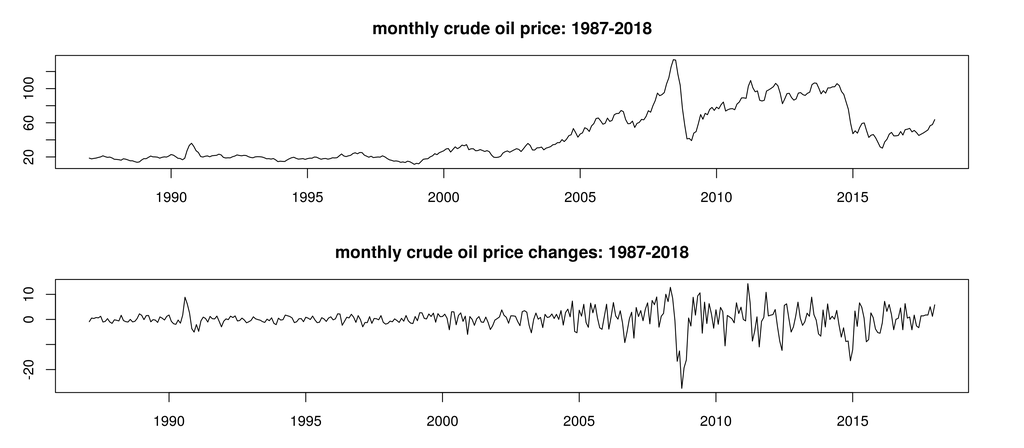

```r
par(mfrow=c(2,1));par(mar=c(3,3,3,3))
plot(P, main="monthly crude oil price: 1987-2018")
plot(r, main="monthly crude oil price changes: 1987-2018")
```

Since the forecast origin is December 2007, we should use the data up to this date to fit the model. The following R code yields AR(1) model

\begin{align*} r_t = 0.2877 + 0.1542 (r_{t-1} - 0.2877) + \eps_t;\quad \sigh_\eps^2= 5.931. \end{align*}

```r
r_train = window(r, start=NULL, end=c(2007,12))
fit_ar = arima(r_train, order=c(1,0,0))
fit_ar
```

```
Call:
arima(x = r_train, order = c(1, 0, 0))

Coefficients:
         ar1  intercept
      0.1542     0.2877
s.e.  0.0625     0.1816

sigma^2 estimated as 5.931:  log likelihood = -579.58,  aic = 1165.16
```

The 1-to-12-step-ahead predictions are as follows

```r
print(predict(fit_ar,12))
```

```
$pred
            Jan        Feb        Mar        Apr        May        Jun
2008 -0.2315946  0.2076145  0.2753383  0.2857809  0.2873911  0.2876394
            Jul        Aug        Sep        Oct        Nov        Dec
2008  0.2876777  0.2876836  0.2876845  0.2876846  0.2876846  0.2876846

$se
          Jan      Feb      Mar      Apr      May      Jun      Jul      Aug
2008 2.435382 2.464164 2.464844 2.464860 2.464861 2.464861 2.464861 2.464861
          Sep      Oct      Nov      Dec
2008 2.464861 2.464861 2.464861 2.464861
```

The following function shows the prediction interval along with the time series.

```r
predplot = function(data, model, origin, horizon, xlim=NULL, ylim=NULL, main=NULL, legloc="topleft"){
    pr = predict(model,horizon)
    plot(data, ylim=ylim, xlim=xlim, type='l', main=main)
    lines(ts(pr$pred, start=origin, frequency=frequency(data)), type='p', lty=1, pch='*')
    lines(ts(pr$pred+1.96*pr$se, start=origin, frequency=frequency(data)), type='l', lty=2,col=2)
    lines(ts(pr$pred-1.96*pr$se, , start=origin, frequency=frequency(data)), type='l', lty=2,col=2)
    legend(legloc,c("data","predictions","lower CL","upper CL"),cex=1.2,
           box.lty=1,pch=c(NA,"*",NA,NA),lty=c(1,NA,2,2), col=c(1,1,2,2))
}
```

The time series plot with prediction intervals is as follows.

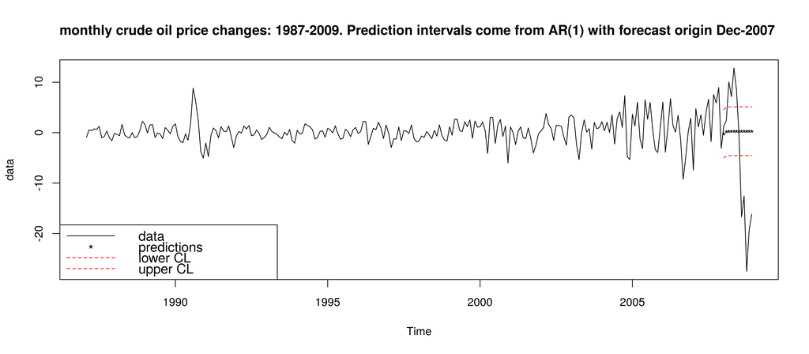

```r
predplot(window(r, start=NULL, end=c(2008,12)), fit_ar, origin=c(2008,1), horizon=12, legloc="bottomleft",
         main=paste("monthly crude oil price changes: 1987-2009.",
                    "Prediction intervals come from AR(1) with forecast origin Dec-2007 "))
```

Similarly, based on the R output below, the fitted MA(2) model is:

\begin{align*} r_t = 0.2866 + \eps_t + 0.1664\, \eps_{t-1} -0.0456\,\eps_{t-2};\quad \sigh_\eps^2= 5.904. \end{align*}

```r
fit_ma = arima(r_train, order=c(0,0,2))
fit_ma
```

```
Call:
arima(x = r_train, order = c(0, 0, 2))

Coefficients:
         ma1      ma2  intercept
      0.1664  -0.0456     0.2866
s.e.  0.0636   0.0702     0.1719

sigma^2 estimated as 5.904:  log likelihood = -579.02,  aic = 1166.03
```

For the MA(2) model, the time series plot with prediction intervals is as follows.

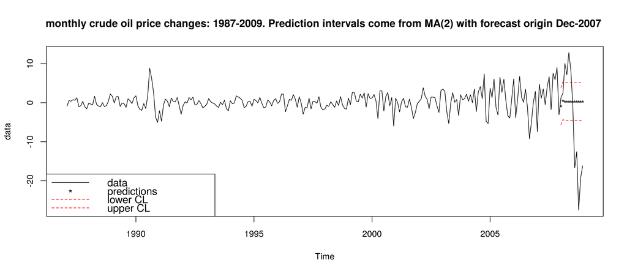

```r
predplot(window(r, start=NULL, end=c(2008,12)), fit_ma,
         origin=c(2008,1), horizon=12, legloc="bottomleft",
         main=paste("monthly crude oil price changes: 1987-2009.",
                    "Prediction intervals come from MA(2) with forecast origin Dec-2007 "))
```

**Remark:** Note that both models perform very badly. There reason for this is that the price change during 2008 was very different from previous years. What happened during 2008 to oil prices (well, and pretty much everything else)?

## (d)

(4 points) One way to evaluate the quality of a time series model is to measure its "out-of-sample" predictive power. Consider a time series process $\{r_t\}_{t=1}^T$. Recall that $\rh_t(h)$ denotes the h-step ahead forecast at time $t$, which estimates $r_{t+h}$ given the information $r_1, \dots, r_t$. In particular, note that to find $\rh_t(h)$ we should fit a model to the sample $r_1, \dots, r_t$, while to find $\rh_{t+1}(h)$ we should fit a model to the sample $r_1$, \dots, $r_{t+1}$. We define the out-of-sample root mean square errors (RMSE) for h-step ahead forecasts as follows

\begin{align*} RMSE(h) :=\sqrt{\frac{1}{T-h-t_0+1} \sum_{t=t_0}^{T-h}\left(r_{t+h} - \rh_t(h)\right)^2}. \end{align*}

A smaller value of RMSE(h) indicates a better predictive power for the model. For the two models in part (c), find RMSE(1), RMSE(2), and RMSE(3). Assume that $t_0$ is December 2007 and $T$ is January 2018. Which model has a better predictive power?

**Solution:** Let us write a function to calculate RMSE(h).

```r
arima_rmse = function(data, origin, horizon=1,
                      order = c(0L, 0L, 0L),
                      seasonal=list(order = c(0L, 0L, 0L), period = NA),
                      initParam = FALSE){
    t0 = max(which(time(data)<=origin))
    T = length(data)
    sse = rep(0L, horizon)
    h = horizon
    init=NULL
    errorMatrix = matrix(0, nrow=h, ncol=T-t0)
    for (t in (t0:(T-1))){
        train = as.numeric(data[1:t])
        fit = arima(train, order=order, seasonal=seasonal, init=init)
        if (initParam) {
         init= coef(fit)
        }
        error = (as.numeric(data[(t+1):(t+h)]-predict(fit, h)$pred))^2
        if (t> T-horizon){
            h =  h - 1
            error = append(error[1:h], rep(0L,horizon-h))
        }
        errorMatrix[,t-t0+1] = error
        sse = sse + error
    }
    return(list(rmse=sqrt(sse / ((T-t0):(T-horizon-t0+ 1))),
                errorMatrix=errorMatrix))
}
```

**Remark:** Note that one call of the function calculates RMSE(1),..., RMSE(h). However, we use the out-of-sample window is not the same for different RMSE's. Specifically, RMSE(h) has $T-h-t_0+1$ error terms. The code above accounts for this. The function also returns the forecast errors at each day of out-of-sample window.

**Remark:** You can use the `init=` argument of arima function to pass the fitted values of the model estimated in the previous step as the initial values for the parameters. This will speed up fitting the model.

**Remark:** The `arima_rmse` function allows for seasonal specification, and will be used in question 2.(d).

For AR(1) model, the values are RMSE(1) = 6.142, RMSE(2) = 6.630, and RMSE(3)= 6.782.

```r
arima_rmse(r, order=c(1,0,0), origin=2008, horizon=3)$rmse
```

1. 6.14213688844514

2. 6.63013482099429

3. 6.78229060669509

For MA(2) model, the values are RMSE(1) = 6.129, RMSE(2) = 6.669, and RMSE(3)= 6.739.

```r
arima_rmse(r, order=c(0,0,2), origin=2008, horizon=3)$rmse
```

1. 6.12924196152725

2. 6.66895675211256

3. 6.73946151823348

So, MA(2) model is better at forecasting 1 and 3 steps ahead, while AR(1) is better at forecasting 2 steps ahead.

# 2

(20 points) Consider the monthly new one family houses sold in the U.S. from January 1963 to present. The data can be obtained by the following R code:

[output not shown]

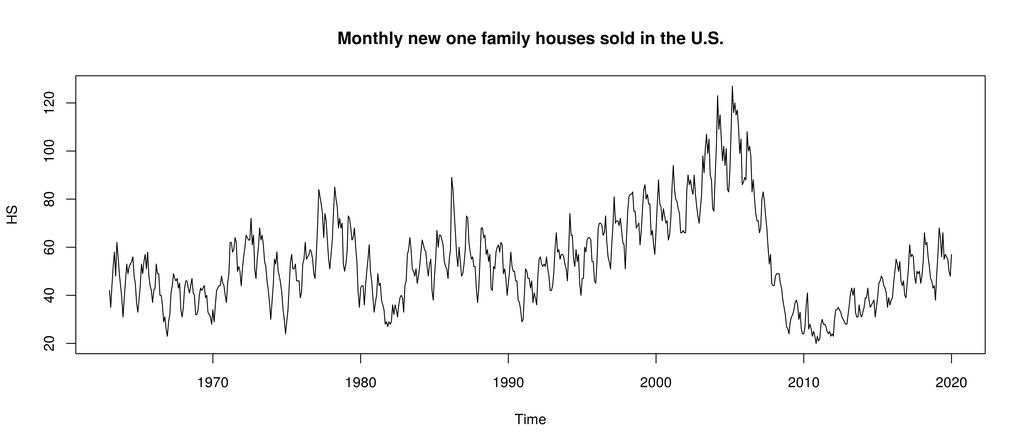

```r
library(quantmod)
HS = getSymbols("HSN1FNSA",src="FRED", auto.assign=FALSE)
HS = ts(as.numeric(HS), start = c(1963,1), frequency = 12)
plot.ts(HS, main="Monthly new one family houses sold in the U.S.")
```

Let HS={HS$_t$} be the time series of house-sold data.

## (a)

(1 points) Find the sample ACF plot of dHS$:=\Del HS$. What is the periodicity of dHS based on this plot?

**Solution:**

Sample ACF plot suggests a periodicity of 12, since there is persistent autocorrelation at lags 12, 24, 36, 48,...

```r
dHS=diff(HS)
```

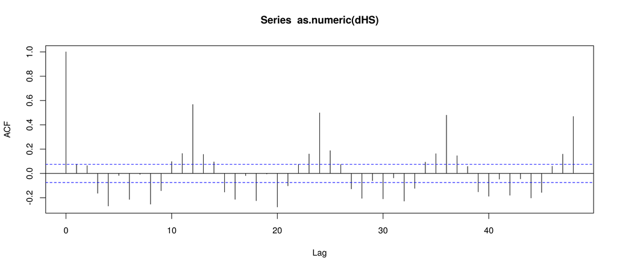

```r
acf(as.numeric(dHS), lag.max=48)
```

## (b)

(8 points) Build an Airline model for HS. You should perform model checking. Write down the fitted model. Plot HS with 12-step ahead (i.e. 1 year into the future) forecasts and prediction intervals (Hint: see output [27] of Lecture 10).

**Solution:**

The fitted airline model is

\begin{align*} \begin{cases} \Del\Del_{12} HS_t = (1-0.223 B)(1-0.8722 B^{12}) \eps_t,\\ \eps_t\sim \text{weak WN}(0,\sig_\eps^2=20.68) \end{cases} \end{align*}

```r
HS_airline = arima(HS, order=c(0,1,1), seasonal=list(order=c(0,1,1), period=12))
HS_airline
```

```
Call:
arima(x = HS, order = c(0, 1, 1), seasonal = list(order = c(0, 1, 1), period = 12))

Coefficients:
         ma1     sma1
      -0.223  -0.8722
s.e.   0.041   0.0337

sigma^2 estimated as 20.68:  log likelihood = -1979.88,  aic = 3965.76
```

Model checking indicates that that there the residuals are autocorrelated. So, the mean equation is not adequate.

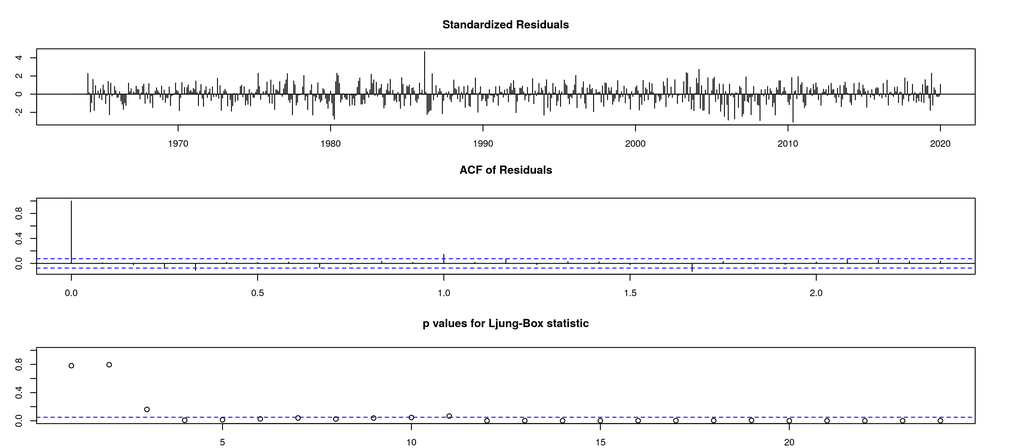

```r
par(mar=c(2,3,4,4))
tsdiag(HS_airline, gof=24)
```

The plot of HS with 12-step-ahead forecasts are as follows. We used the function `predplot` from question 1.(c).

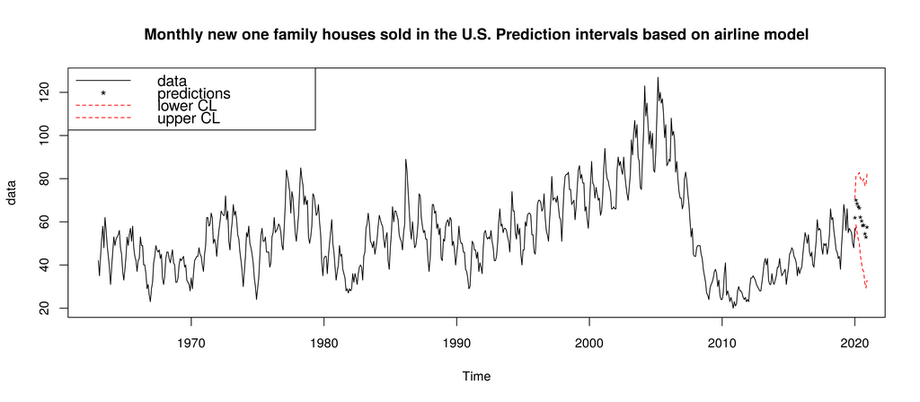

```r
predplot(HS, HS_airline, origin=c(2020,1), horizon=12, legloc="topleft",
         main=paste("Monthly new one family houses sold in the U.S.",
                    "Prediction intervals based on airline model"))
```

We may zoom in a bit in the most recent data to see the trend more clearly.

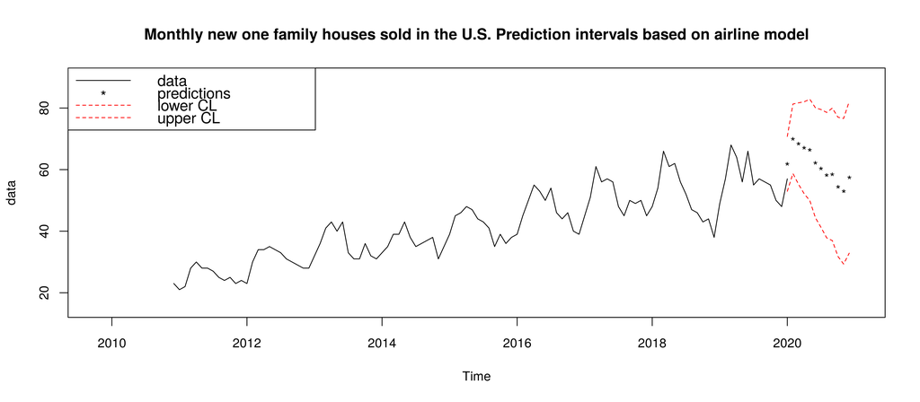

```r
predplot(window(HS, start=c(2010,12)), HS_airline, origin=c(2020,1),
         horizon=12, legloc="topleft", xlim=c(2009.8, 2021), ylim=c(15,90),
         main=paste("Monthly new one family houses sold in the U.S.",
                    "Prediction intervals based on airline model"))
```

## (c)

(8 points) Repeat part (b), but this time use ``auto.arima()'' function with BIC to build a model for dHS$:=\Del$HS.

**Solution:**

`auto.arima()` suggests a SARIMA(1,0,1)$\times$(3,0,0) model for $\{\text{dHS}_t\}$:

\begin{align*} \begin{cases} (1-0.5376 B)(1-0.3920 B^{12} - 0.1931 B^{24} - 0.1925 B^{36}) \text{dHS}_t = (1-0.7291 B) \eps_t,\\ \eps_t\sim \text{weak WN}(0,\sig_\eps^2=22.36) \end{cases} \end{align*}

Note that there is **NO** seasonal differencing in this model. Instead, the lagged values of 1, 2, and 3 yeas in the past contribute to the seasonal AR component.

```r
library(forecast)
dHS_sarima = auto.arima(dHS, ic="bic",
                        max.p=20, max.q = 20, max.d=3,
                        max.P=20, max.Q = 20, max.D=3)
dHS_sarima
```

```
Series: dHS
ARIMA(1,0,1)(3,0,0)[12] with zero mean

Coefficients:
         ar1      ma1    sar1    sar2    sar3
      0.5376  -0.7291  0.3920  0.1931  0.1925
s.e.  0.0938   0.0745  0.0385  0.0411  0.0389

sigma^2 estimated as 22.36:  log likelihood=-2035.34
AIC=4082.68   AICc=4082.8   BIC=4109.85
```

The mean specification of this model is adequate, as the residuals are weak WN according to the Ljung-Box test.

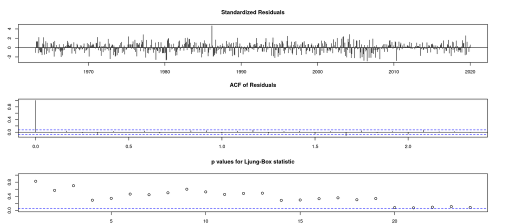

```r
par(mar=c(2,3,4,4))
tsdiag(dHS_sarima, gof=24)
```

The residual$^2$ seems to be autocorrelated and show variance clustering. The normal probability plot indicates normality. The normality test, however, indicates non-normality. We should consider a volatility model for the innovations.

```r
tsdiag_vol = function(model, lag, fitdf, span=0.5){
    par(mfrow=c(1,2));par(mar=c(3,3,3,3))
    plot(as.numeric(resid(model)**2), type="l", col=1,
         main = expression(residual^2))
    smoother = loess((resid(model)**2) ~ seq(1,length(resid(model))),
                     span=span)
    lines(seq(1,length(resid(model))),fitted(smoother),col=2)
    acf((resid(model)**2), main=expression("sample ACF of "~ residual^2))
    Box.test(resid(model)**2, lag = lag, type = "Ljung-Box", fitdf = fitdf)
}
tsdiag_norm = function(model){
    qqnorm(resid(model), datax = FALSE,
       xlab = "normal quantile",
       ylab = "sample quantile of residuals",
       main = "normal probability plot for residuals")
    qqline(resid(model), datax=FALSE, col = 2)
    shapiro.test(resid(model))
}
```

```
	Box-Ljung test

data:  resid(model)^2
X-squared = 21.832, df = 7, p-value = 0.002715
```

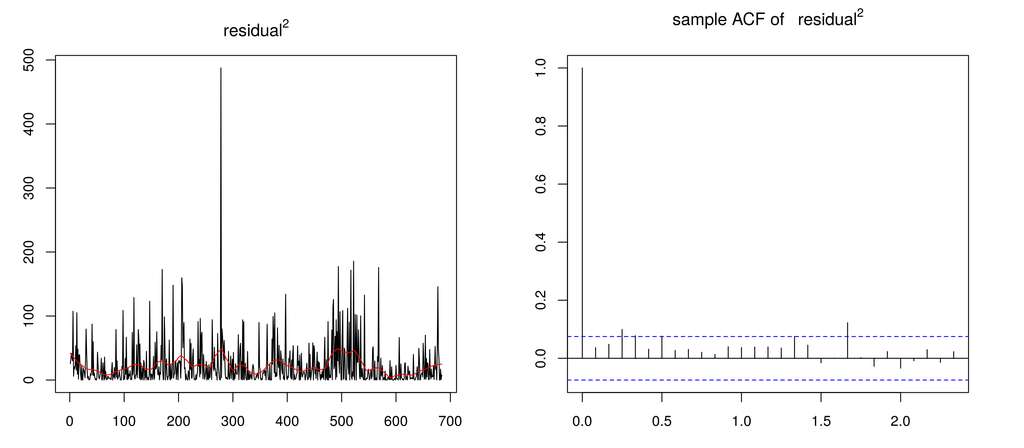

```r
tsdiag_vol(dHS_sarima, lag=12, fitdf=5, span=0.1)
```

```
	Shapiro-Wilk normality test

data:  resid(model)
W = 0.99451, p-value = 0.0144
```

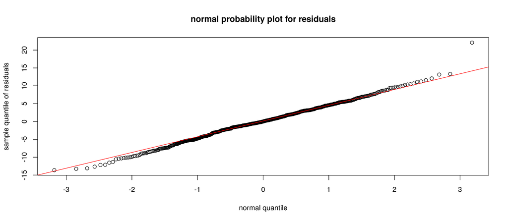

```r
tsdiag_norm(dHS_sarima)
```

## (d)

(3 points) Compare the Models in part (b) and (c). Use in-sample comparison based on BIC. Also, use out-of-sample comparison using RMSE(1), RMSE(2),$\dots$ RMSE(12) that was defined in Question 1 part (d). Assume that $t_0$ is January 2000 and $T$ is November 2018.

**Solution:** We may re-use the `arima_rmse()` function from question 1.(d) to calculate the RMSE values for the airline and Seasonal model.

```r
library(tictoc)
tic()
rmse_airline = arima_rmse(dHS, origin=2000, horizon=12,
                          order = c(0, 0, 1),
                          seasonal=list(order=c(0,1,1), period=12))
rmse_airline$rmse
toc()
```

1. 4.82095253138283

2. 4.98942505228662

3. 5.00164460824132

4. 4.98128468054512

5. 4.99027640676036

6. 4.99206410127947

7. 4.97863086746493

8. 4.98076217613224

9. 4.98642012126084

10. 4.99660708710951

11. 5.00502950747518

12. 4.99974507930403

```
15.068 sec elapsed
```

```r
tic()
rmse_sarima = arima_rmse(dHS, origin=2000, horizon=12,
                         order = c(1, 0, 1),
                         seasonal=list(order=c(3,0,0), period=12))
rmse_sarima$rmse
toc()
```

1. 4.7532413763339

2. 4.93414698113175

3. 4.9051122548219

4. 4.88920648632557

5. 4.92251900463676

6. 4.89671313175504

7. 4.88229071562733

8. 4.8725479031691

9. 4.8826503671261

10. 4.88534676453666

11. 4.88403432405748

12. 4.86932583278382

```
263.714 sec elapsed
```

The plot below clearly shows that SARIMA model of part 1.(c) has a better out-of-sample performance than the airline model.

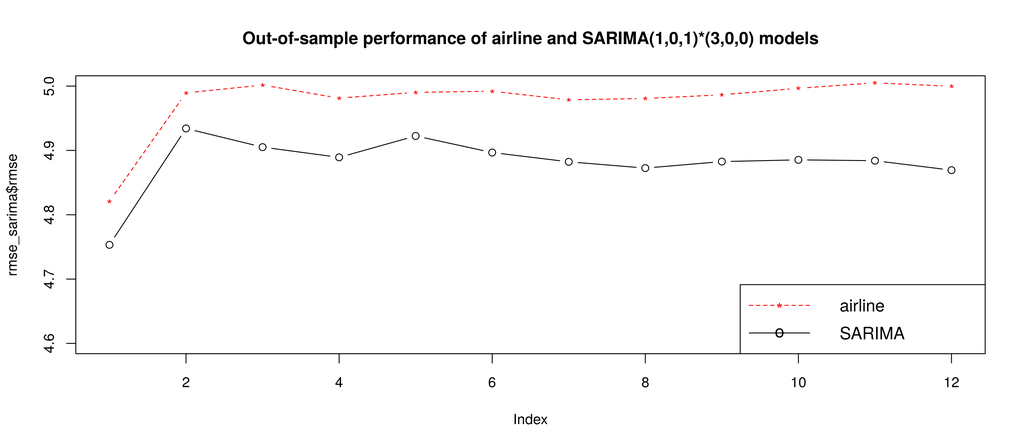

```r
plot(rmse_sarima$rmse, type="b", ylim=c(4.6,5),
     main= "Out-of-sample performance of airline and SARIMA(1,0,1)*(3,0,0) models")
lines(rmse_airline$rmse, type="b", col='red', pch="*", lty=2)
legend("bottomright",c("airline","SARIMA"),cex=1.2, y.intersp=2,
       box.lty=1,pch=c("*","o"),lty=c(2,1), col=c(2,1))
```

**Remark:** The `arima_rmse()` function is rather slow. As the output above indicates, it took 15sec for the airline model and almost 4.5 minutes for the SARIMA model (on a 24-core machine).

To improve the computation time, we can try to parallelize the loop inside the function. For this, you can use the `foreach` and `doParallel` packages in R.

```r
library(foreach)
library(doParallel)
detectCores()
```

24

The parallel version of the `arima_rmse()` is as follows.

```r
arima_rmse_parallel = function(data, origin, horizon=1,
                               order = c(0L, 0L, 0L),
                               seasonal=list(order = c(0L, 0L, 0L), period = NA)){
    # start cluster
    cluster = makeCluster(detectCores()[1]-1)
    registerDoParallel(cluster)
    t0 = max(which(time(data)<=origin))
    T = length(data)
    errorMatrix = foreach(t=(t0:(T-1)), .combine=cbind) %dopar% {
        train = as.numeric(data[1:t])
        fit = arima(train, order=order, seasonal=seasonal)
        h = min(horizon, T - t)
        error = (as.numeric(data[(t+1):(t+h)]-predict(fit, h)$pred))^2
        if (t+horizon>T){
            error = append(error[1:h], rep(0L,horizon-h))
        }
        error
    }
    #stop cluster
    stopCluster(cluster)
    sse = rowSums(errorMatrix)
    return(list(rmse=sqrt(sse / ((T-t0):(T-horizon-t0+ 1))),
                errorMatrix=errorMatrix))
}
```

The parallel version of the function takes 5 seconds for the airline model and 30 seconds for the SARIMA model. This is a significant improvement without spending much effort (well, other than having access to a multi-core machine).

```r
tic()
rmse_airline = arima_rmse_parallel(dHS, origin=2000, horizon=12,
                                   order = c(0, 0, 1),
                                   seasonal=list(order=c(0,1,1), period=12))
rmse_airline$rmse
toc()
```

1. 4.82095253138283

2. 4.98942505228663

3. 5.00164460824133

4. 4.98128468054512

5. 4.99027640676036

6. 4.99206410127947

7. 4.97863086746493

8. 4.98076217613224

9. 4.98642012126084

10. 4.99660708710951

11. 5.00502950747518

12. 4.99974507930403

```
4.779 sec elapsed
```

```r
tic()
rmse_sarima = arima_rmse_parallel(dHS, origin=2000, horizon=12,
                                   order = c(1, 0, 1),
                                   seasonal=list(order=c(3,0,0), period=12))
rmse_sarima$rmse
toc()
```

1. 4.7532413763339

2. 4.93414698113175

3. 4.9051122548219

4. 4.88920648632557

5. 4.92251900463676

6. 4.89671313175504

7. 4.88229071562732

8. 4.8725479031691

9. 4.8826503671261

10. 4.88534676453666

11. 4.88403432405748

12. 4.86932583278382

```
30.246 sec elapsed
```

# 3

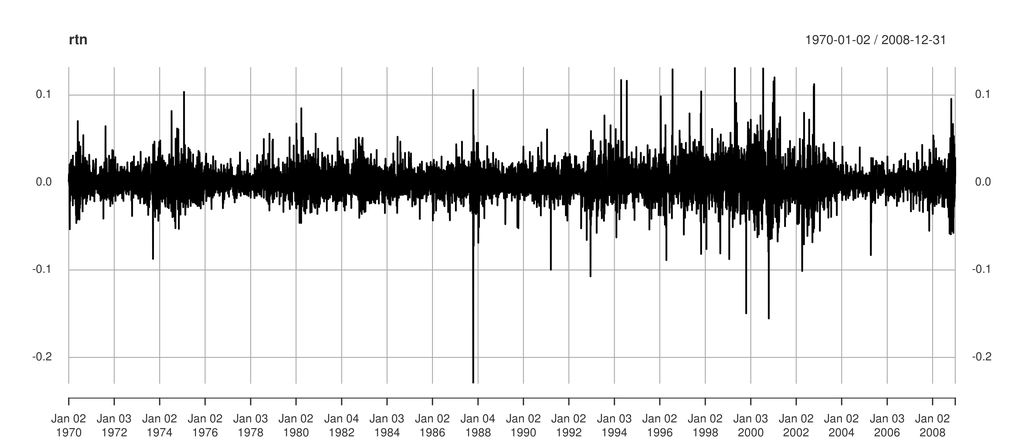

```r
library(xts)
dat = read.table("HW5-Q3.txt",header=T)
rtn = xts(dat[,2], order.by=as.Date(as.character(dat[, 1]),"%Y%m%d"))
plot(rtn)
```

## (a)

(4 points) Let $a = \{a_t:=|\text{rtn}_t|\}$ be \textbf{the absolute values} of daily simple returns of IBM stock. Test if $\{a_t\}$ is stationary using ADF, PP, and KPSS tests. Also, compute the first 100 lags of the sample ACF of $\{a_t\}$. Is there evidence of long memory? Why?

**Solution:** Let us define $a$ as $|rtn|$:

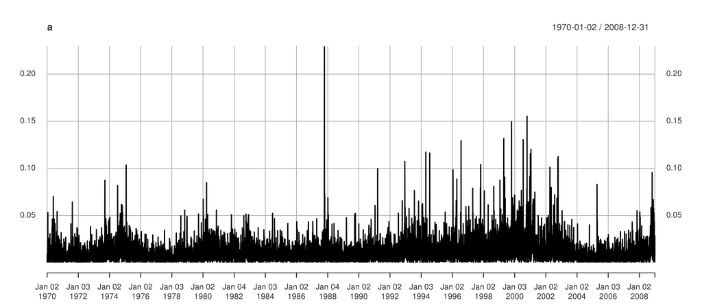

```r
a = abs(rtn)
plot(a)
```

The ADF and PP tests indicate that ${a_t}$ is stationary, while KPSS indicates that it is nonstationary. The sample ACF plot has low but persistent autocorrelation. These are indications of a long memory processes.

```
	Augmented Dickey-Fuller Test

data:  a
Dickey-Fuller = -11.622, Lag order = 21, p-value = 0.01
alternative hypothesis: stationary
```

```
	Phillips-Perron Unit Root Test

data:  a
Dickey-Fuller Z(alpha) = -12536, Truncation lag parameter = 12, p-value
= 0.01
alternative hypothesis: stationary
```

```
	KPSS Test for Level Stationarity

data:  a
KPSS Level = 5.4257, Truncation lag parameter = 12, p-value = 0.01
```

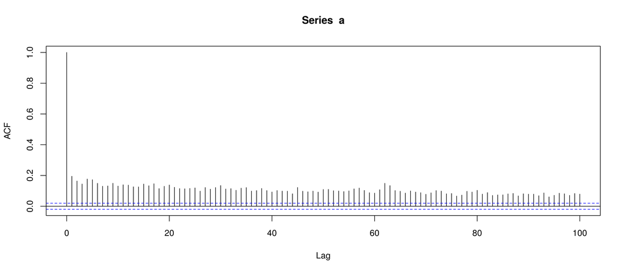

```r
library(tseries)
adf.test(a)
pp.test(a)
kpss.test(a)
acf(a, lag.max = 100)
```

## (b)

(6 point) Build an ARFIMA model for $\{a_t\}$. You should perform model checking. Write down the fitted model (Hint: see Section 1.1 of Lecture 10).

**Solution:** First, we estimate the order of fractional differencing by using `fracdiff()` function.

```r
library(fracdiff)
absrtn = coredata(a)
d = coef(fracdiff(absrtn,nar=0,nma=0))
d
```

**d:** 0.171556813070261

Then, we for the fractionally differenced series. It sample ACF looks better than the original series now.

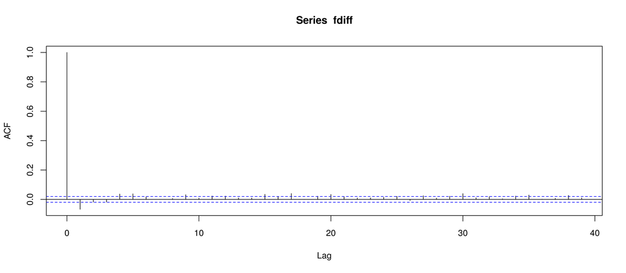

```r
fdiff = diffseries(absrtn,d)
acf(fdiff)
```

Finally, we use `auto.arima()` to fit a model to the fractionally differenced series. The fitted model is:

\begin{align*} \begin{cases} \Del^{0.17156} a_t = \eps_t -0.0702\,\eps_{t-1},\\ \eps_t \sim \text{weak WN}(0,0.0001305). \end{cases} \end{align*}

```r
farima = auto.arima(as.numeric(fdiff), max.p=20, max.q = 20, max.d=0, ic="bic")
farima
```

```
Series: as.numeric(fdiff)
ARIMA(0,0,1) with zero mean

Coefficients:
          ma1
      -0.0702
s.e.   0.0103

sigma^2 estimated as 0.0001305:  log likelihood=30059.06
AIC=-60114.11   AICc=-60114.11   BIC=-60099.72
```

- The model does not seem to be adequate, however.

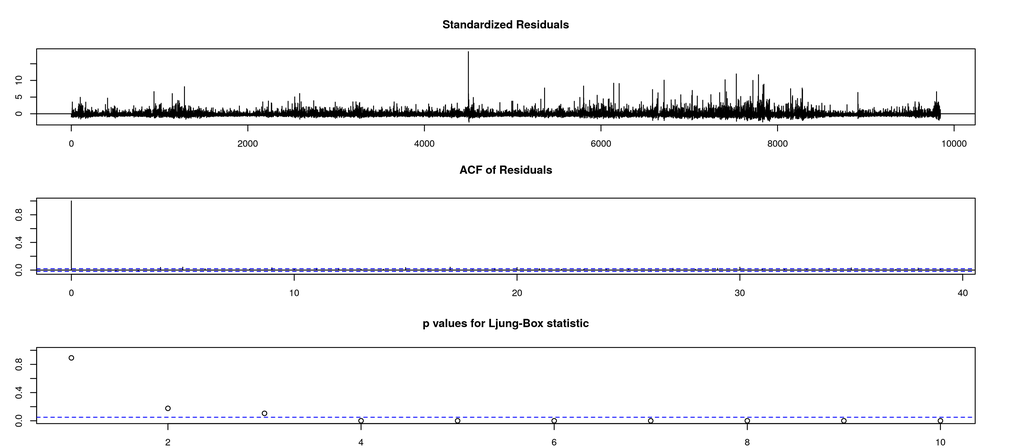

```r
par(mar=c(2,3,4,4))
tsdiag(farima)
```

# 4.

```r
dat = read.table("HW5-Q4.txt",header=T)
s = dat[,1];f = dat[,2]
```

The futures prices are for the June contract. Let $\{s_t\}$ and $\{f_t\}$ be the spot and futures prices, respectively.

## (a)

(2 points) Define $y=\{y_t := \Del f_t\}$ and $x=\{x_t:=\Del s_t\}$. Show the time series plot and the scatter plot of $(x_t,y_t)$. Are $x$ and $y$ correlated?

**Solution:** The time series and scatter plots are below. The returns look mildly correlated. The sample correlation coefficient is $0.3885$.

0.388486253843071

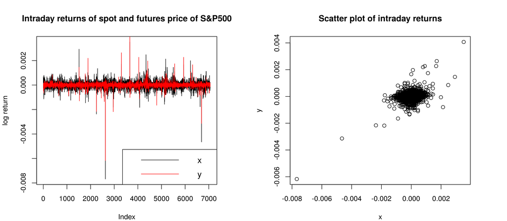

```r
y = na.omit(diff(f))
x = na.omit(diff(s))
par(mfrow=c(1,2));par(mar=c(4,4,4,4))
plot(x, type="l", ylab="log return",
     main="Intraday returns of spot and futures price of S&P500")
lines(y, type="l",col="red")
legend("bottomright",c("x","y"),cex=1.2, y.intersp=2,
       box.lty=1,lty=c(1,1), col=c(1,"red"))
plot(x,y,xlab="x", ylab="y", main="Scatter plot of intraday returns")
cor(x,y)
```

## (b)

(points) Fit a line regression $y_t = \beta_0 + \beta_1 x_t + \eps_t$ using OLS. Write down the fitted model. Is the model spurious regression?

**Solutions:** The fitted OLS regression is

\begin{align*} \begin{cases} y_t = 0.243019\,x_t + \eps_t\\ \eps_t \sim \text{ weak WN}(0, \sig_\eps^2=0.0001844^2) \end{cases} \end{align*}

Note that the intercept $\beta_0$ is insignificant. So, we removed it.

```r
summary(lm(y~x))
```

```
Call:
lm(formula = y ~ x)

Residuals:
       Min         1Q     Median         3Q        Max
-0.0043065 -0.0000782  0.0000010  0.0000803  0.0032125

Coefficients:
             Estimate Std. Error t value Pr(>|t|)
(Intercept) 2.312e-06  2.194e-06   1.054    0.292
x           2.429e-01  6.859e-03  35.420   <2e-16 ***
---
Signif. codes:  0 ‘***’ 0.001 ‘**’ 0.01 ‘*’ 0.05 ‘.’ 0.1 ‘ ’ 1

Residual standard error: 0.0001844 on 7058 degrees of freedom
Multiple R-squared:  0.1509,	Adjusted R-squared:  0.1508
F-statistic:  1255 on 1 and 7058 DF,  p-value: < 2.2e-16
```

```r
fit_ols = lm(y~x-1)
summary(fit_ols)
```

```
Call:
lm(formula = y ~ x - 1)

Residuals:
       Min         1Q     Median         3Q        Max
-0.0043036 -0.0000759  0.0000033  0.0000826  0.0032146

Coefficients:
  Estimate Std. Error t value Pr(>|t|)
x 0.243019   0.006859   35.43   <2e-16 ***
---
Signif. codes:  0 ‘***’ 0.001 ‘**’ 0.01 ‘*’ 0.05 ‘.’ 0.1 ‘ ’ 1

Residual standard error: 0.0001844 on 7059 degrees of freedom
Multiple R-squared:  0.151,	Adjusted R-squared:  0.1509
F-statistic:  1255 on 1 and 7059 DF,  p-value: < 2.2e-16
```

The residuals of the regression seems to be stationary. They are, however, autocorrelated according to the sample ACF plot and Ljung-Box test below. We cannot rule out the possibility that the model is a spurious regression.

**Remark:** This model is probably not a spurious regression, since there is no autocorrelation at longer lags. We should fit an ARIMA model to be sure, though.

```
	KPSS Test for Level Stationarity

data:  resid(fit_ols)
KPSS Level = 0.083953, Truncation lag parameter = 11, p-value = 0.1
```

```
	Box-Pierce test

data:  resid(fit_ols)
X-squared = 139.63, df = 9, p-value < 2.2e-16
```

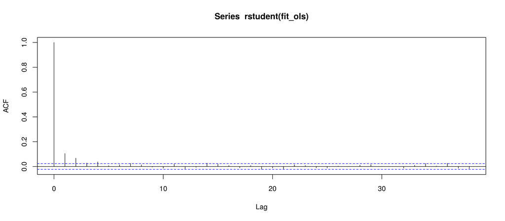

```r
kpss.test(resid(fit_ols))
acf(rstudent(fit_ols))
Box.test(resid(fit_ols), lag=10, fitdf=1)
```

## (c)

(6 points) Build an ARIMAX model for $y$ with $x$ as the predictor. Use `auto.arima()` with BIC to find the model. Perform model checking.

**Solutions:** The fitted model is an ARIMAX(1,0,1) model

\begin{align*} \begin{cases} y_t = 0.2251\,x_t + a_t\\ a_t = 0.6557 a_{t-1} + \eps_t - 0.5549 \eps_{t-1}\\ \eps_t \sim \text{ weak WN}(0, \sig_\eps^2=3.344\,10^{-8}) \end{cases} \end{align*}

or, more compactly,

\begin{align*} \begin{cases} (1-0.6557 B) (y_t - 0.2251\,x_t) = (1-0.5549 B) \eps_t\\ \eps_t \sim \text{ weak WN}(0, \sig_\eps^2=3.344\,10^{-8}) \end{cases} \end{align*}

```r
library(forecast)
fit_arimax = auto.arima(y, max.p=20, xreg = x, max.q = 20, max.d=3, ic="bic")
fit_arimax
```

```
Series: y
Regression with ARIMA(1,0,1) errors

Coefficients:
         ar1      ma1    xreg
      0.6557  -0.5549  0.2251
s.e.  0.0614   0.0676  0.0069

sigma^2 estimated as 3.344e-08:  log likelihood=50747.43
AIC=-101486.9   AICc=-101486.9   BIC=-101459.4
```

The sample ACF plot and Ljung-Box test indicate the the mean specification of the ARIMAX model is adequate. However, the ACF plot of residual$^2$ shows that the residual have non-constant volatility. The normal probability plot shows that residuals are not normal.

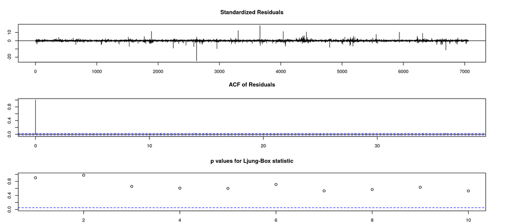

```r
par(mar=c(2,3,4,4))
tsdiag(fit_arimax, gof=10)
```

```
	Box-Ljung test

data:  resid(model)^2
X-squared = 18.06, df = 9, p-value = 0.03448
```

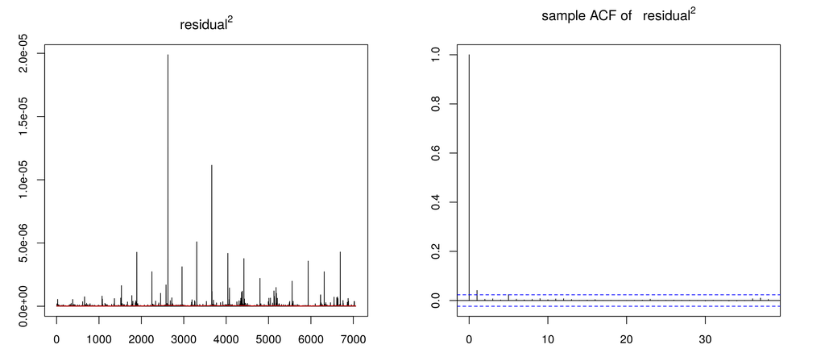

```r
tsdiag_vol(fit_arimax, lag=12, fitdf=3, span=0.25)
```

```
Error in shapiro.test(resid(model)): sample size must be between 3 and 5000
Traceback:

1. tsdiag_norm(fit_arimax)
2. shapiro.test(resid(model))   # at line 17 of file <text>
3. stop("sample size must be between 3 and 5000")
```

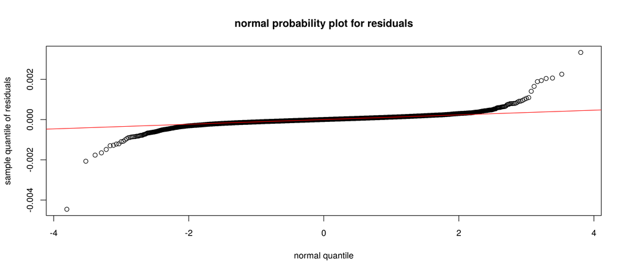

```r
tsdiag_norm(fit_arimax)
```

**Remark:** Note that the `shapiro.test()` does not work for sample size larger than 5000. In this problem, the normal probability plot clearly shows non-normality. To be confident, we can use another normality test, such as the Kolmogorov-Smirnov test. The test indicates non-normality, as expected.

```r
ks.test(resid(fit_arimax), y="pnorm")
```

```
	One-sample Kolmogorov-Smirnov test

data:  resid(fit_arimax)
D = 0.49903, p-value < 2.2e-16
alternative hypothesis: two-sided
```